# Inferencia estadística I

Modelos, estimación, intervalos de confianza y la distribución empírica

Autor/a

Alejandro Veloz

Este apunte es el primero de cinco que reemplazan la clase de inferencia estadística de INF396. Sigue los capítulos 6 y 7 de Wasserman, *All of Statistics*. El orden de lectura es el siguiente.

| Apunte | Contenido | Capítulos |
| --- | --- | --- |
| I. Marco de la inferencia | Modelos, estimación puntual, intervalos de confianza, distribución empírica, funcionales | 6 y 7 |
| II. Bootstrap | Error estándar por simulación, tres intervalos, cuándo falla | 8 |
| III. Inferencia paramétrica | Momentos, verosimilitud, propiedades del EMV, método delta | 9 |
| IV. Contraste de hipótesis | Tests, valor $p$, potencia y tamaño de muestra, comparaciones múltiples, *p-hacking* | 10 |
| V. Inferencia bayesiana | Prior, posterior, comparación con el enfoque frecuentista | 11 |

Cada apunte tiene ejemplos en Python que se pueden copiar y ejecutar. Los cinco usan sólo `numpy`, `scipy` y `matplotlib`.

# 1 El problema de la inferencia

La inferencia estadística es el proceso de usar datos para inferir la distribución que los generó. La pregunta típica es la siguiente: dada una muestra $X_1, \ldots, X_n \sim F$, ¿qué podemos decir sobre $F$? A veces interesa sólo alguna característica de $F$, como su media.

Un **modelo estadístico** $\mathfrak{F}$ es un conjunto de distribuciones. Un modelo **paramétrico** es un conjunto que se puede describir con un número finito de parámetros,
$$\mathfrak{F} = \{f(x;\theta) : \theta \in \Theta\},$$
donde $\theta$ es el parámetro y $\Theta$ el espacio de parámetros. La familia normal, con $\theta = (\mu, \sigma)$, es el ejemplo canónico. Un modelo **no paramétrico** es un conjunto que no admite esa descripción, como $\mathfrak{F}_{\text{ALL}}$, el conjunto de todas las funciones de distribución. Si $\theta$ es un vector y sólo interesa una componente, las restantes se llaman **parámetros de ruido** (*nuisance parameters*).

Consideremos algunos ejemplos que fijan el vocabulario. Estimar $p$ a partir de $X_1, \ldots, X_n \sim \text{Bernoulli}(p)$ es un problema paramétrico unidimensional. Estimar $F$ suponiendo sólo que $F \in \mathfrak{F}_{\text{ALL}}$ es no paramétrico. Estimar la densidad $f = F'$ requiere suponer algo más, por ejemplo que $f$ es suave; sin ese supuesto no es posible. Estimar la media $\mu = \int x\,dF(x)$ suponiendo sólo que existe es un problema no paramétrico sobre un **funcional estadístico**, es decir, una función $T(F)$ de la distribución. En regresión se observan pares $(X_i, Y_i)$ y el objeto de interés es la función de regresión $r(x) = \mathbb{E}(Y \mid X = x)$; el modelo es paramétrico si $r$ pertenece a una familia de dimensión finita, como las rectas, y no paramétrico si no. Predecir $Y$ para un nuevo $X$ se llama predicción, y clasificación si $Y$ es discreta.

Este material sigue el orden de Wasserman y comienza por la inferencia no paramétrica, porque requiere menos maquinaria y permite ver qué aporta cada supuesto adicional cuando se introduce un modelo paramétrico. Todo lo que sigue hasta el apunte IV es inferencia **frecuentista**; el enfoque bayesiano se trata en el apunte V.

Una convención de notación. En un modelo paramétrico, $\mathbb{P}_\theta(X \in A) = \int_A f(x;\theta)\,dx$ y $\mathbb{E}_\theta(r(X)) = \int r(x) f(x;\theta)\,dx$. El subíndice indica que la probabilidad se calcula bajo $f(x;\theta)$, y no que se promedie sobre $\theta$.

# 2 Los tres problemas

La mayoría de los problemas de inferencia pertenece a uno de tres tipos: estimación puntual, conjuntos de confianza y contraste de hipótesis.

## 2.1 Estimación puntual

Una estimación puntual es una única conjetura sobre una cantidad de interés, sea un parámetro, una distribución $F$, una densidad, una función de regresión o una predicción. Se denota $\hat\theta$ o $\hat\theta_n$. El parámetro $\theta$ es una cantidad fija y desconocida; la estimación $\hat\theta_n = g(X_1, \ldots, X_n)$ depende de los datos y por tanto es una variable aleatoria.

El **sesgo** de un estimador es $\operatorname{sesgo}(\hat\theta_n) = \mathbb{E}_\theta(\hat\theta_n) - \theta$. El estimador es insesgado si $\mathbb{E}_\theta(\hat\theta_n) = \theta$. La insesgadez recibió mucha atención en el pasado y hoy se considera menos importante; muchos estimadores útiles son sesgados. Un requisito más razonable es que el estimador converja al valor verdadero al acumular datos.

**Definición.** Un estimador $\hat\theta_n$ es **consistente** si $\hat\theta_n \xrightarrow{P} \theta$.

La distribución de $\hat\theta_n$ se llama **distribución muestral**. Su desviación estándar es el **error estándar**,
$$\operatorname{se} = \operatorname{se}(\hat\theta_n) = \sqrt{\mathbb{V}(\hat\theta_n)}.$$
Con frecuencia el error estándar depende de $F$, desconocida, y hay que estimarlo; la estimación se denota $\widehat{\operatorname{se}}$.

La calidad de un estimador se mide con el **error cuadrático medio**, $\operatorname{ECM} = \mathbb{E}_\theta(\hat\theta_n - \theta)^2$, y se descompone como
$$\operatorname{ECM} = \operatorname{sesgo}^2(\hat\theta_n) + \mathbb{V}_\theta(\hat\theta_n).$$
La demostración consiste en sumar y restar $\bar\theta_n = \mathbb{E}_\theta(\hat\theta_n)$ dentro del cuadrado y observar que el término cruzado tiene esperanza nula. De la descomposición se sigue que si el sesgo y el error estándar tienden a cero, el ECM tiende a cero y el estimador es consistente. Esta descomposición es la misma que en la unidad 2 justificó la elección del ancho del histograma y en la unidad 3 justificó la penalización.

**Ejemplo.** Sea $X_1, \ldots, X_n \sim \text{Bernoulli}(p)$ y $\hat p_n = n^{-1}\sum_i X_i$. Entonces $\mathbb{E}(\hat p_n) = p$, de modo que el estimador es insesgado, $\operatorname{se} = \sqrt{p(1-p)/n}$ y $\widehat{\operatorname{se}} = \sqrt{\hat p_n(1-\hat p_n)/n}$. Como el sesgo es cero y $\operatorname{se} \to 0$, el estimador es consistente.

Muchos estimadores tienen, aproximadamente, distribución normal. Un estimador es **asintóticamente normal** si
$$\frac{\hat\theta_n - \theta}{\operatorname{se}} \rightsquigarrow N(0,1).$$

El siguiente experimento muestra la distribución muestral de $\hat p_n$ y comprueba el error estándar teórico.

```
se teórico  = 0.0648
se empírico = 0.0645
sesgo empírico = -0.0006
```

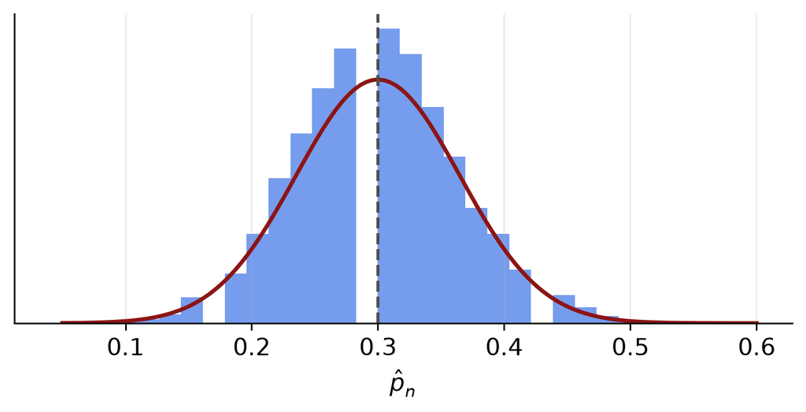

Distribución muestral de la proporción estimada con n = 50 y p = 0,3, sobre diez mil muestras, con la normal asintótica superpuesta.

```python
p, n, R = 0.3, 50, 10_000
phat = rng.binomial(n, p, R) / n
print("se teórico  = %.4f" % np.sqrt(p*(1-p)/n))
print("se empírico = %.4f" % phat.std())
print("sesgo empírico = %.4f" % (phat.mean() - p))
fig, ax = plt.subplots(figsize=(7, 2.8))
ax.hist(phat, bins=30, density=True, color=MYBLUE, alpha=.7)
g = np.linspace(0.05, 0.6, 300)
ax.plot(g, stats.norm.pdf(g, p, np.sqrt(p*(1-p)/n)), color=MYRED, lw=2)
ax.axvline(p, color=GRAY, ls="--"); ax.set_xlabel("$\\hat p_n$"); ax.set_yticks([])
plt.show()
```

## 2.2 Conjuntos de confianza

Un **intervalo de confianza** de nivel $1-\alpha$ para $\theta$ es un intervalo $C_n = (a, b)$, con $a = a(X_1, \ldots, X_n)$ y $b = b(X_1, \ldots, X_n)$ funciones de los datos, tal que
$$\mathbb{P}_\theta(\theta \in C_n) \ge 1 - \alpha \quad \text{para todo } \theta \in \Theta.$$
En palabras, $(a, b)$ atrapa a $\theta$ con probabilidad $1-\alpha$. El número $1-\alpha$ se llama **cobertura**. Lo habitual es $\alpha = 0{,}05$. Si $\theta$ es un vector se usa un conjunto de confianza (una esfera o una elipse) en lugar de un intervalo.

Es importante fijar qué es aleatorio. $C_n$ es aleatorio y $\theta$ es fijo. Un intervalo de confianza no es una afirmación de probabilidad sobre $\theta$, porque $\theta$ no es una variable aleatoria. Algunos textos lo interpretan diciendo que si se repite el experimento muchas veces, el intervalo contendrá al parámetro el 95 % de las veces. Esto es correcto, pero rara vez se repite el mismo experimento. Una interpretación más útil es la siguiente. El día 1 se recogen datos y se construye un intervalo del 95 % para un parámetro $\theta_1$. El día 2 se recogen datos nuevos y se construye un intervalo del 95 % para un parámetro no relacionado $\theta_2$. Y así sucesivamente. Entonces el 95 % de esos intervalos atrapa al parámetro correspondiente. No hace falta imaginar la repetición del mismo experimento. Las encuestas de opinión que reportan “83 % con un margen de 4 puntos” están entregando exactamente un intervalo del 95 % de esta clase.

Un ejemplo de Berger y Wolpert muestra hasta qué punto un intervalo de confianza no es una afirmación de probabilidad sobre $\theta$. Sea $\theta$ un número fijo, $X_1, X_2$ independientes con $\mathbb{P}(X_i = 1) = \mathbb{P}(X_i = -1) = 1/2$ y se observa sólo $Y_i = \theta + X_i$. Definamos $C = \{Y_1 - 1\}$ si $Y_1 = Y_2$ y $C = \{(Y_1 + Y_2)/2\}$ si $Y_1 \neq Y_2$. Se comprueba que $\mathbb{P}_\theta(\theta \in C) = 3/4$ para todo $\theta$, de modo que $C$ es un intervalo de confianza del 75 %. Si se observa $Y_1 = 15$ e $Y_2 = 17$, el intervalo es $\{16\}$, y sin embargo en ese caso estamos seguros de que $\theta = 16$. No hay nada incorrecto en llamar a $\{16\}$ intervalo del 75 %, pero no es una afirmación de probabilidad sobre $\theta$. Los intervalos bayesianos del apunte V sí son afirmaciones de probabilidad sobre $\theta$, en el sentido de grado de creencia, y en general no atrapan al parámetro el 95 % de las veces.

Hay dos formas de construir intervalos. La primera usa una desigualdad válida para todo $n$. En el caso Bernoulli, la desigualdad de Hoeffding da que $C_n = (\hat p_n - \epsilon_n, \hat p_n + \epsilon_n)$ con $\epsilon_n^2 = \log(2/\alpha)/(2n)$ cumple $\mathbb{P}(p \in C_n) \ge 1 - \alpha$ para todo $p$ y todo $n$. La segunda usa la normalidad asintótica.

**Teorema (intervalo basado en la normal).** Supongamos que $\hat\theta_n \approx N(\theta, \widehat{\operatorname{se}}^2)$. Sea $z_{\alpha/2} = \Phi^{-1}(1 - \alpha/2)$, es decir, $\mathbb{P}(Z > z_{\alpha/2}) = \alpha/2$ para $Z \sim N(0,1)$. Sea
$$C_n = \big(\hat\theta_n - z_{\alpha/2}\,\widehat{\operatorname{se}},\; \hat\theta_n + z_{\alpha/2}\,\widehat{\operatorname{se}}\big).$$
Entonces $\mathbb{P}_\theta(\theta \in C_n) \to 1 - \alpha$.

La demostración se reduce a escribir el evento $\theta \in C_n$ como $-z_{\alpha/2} < (\hat\theta_n - \theta)/\widehat{\operatorname{se}} < z_{\alpha/2}$ y aplicar la convergencia a la normal. Para el 95 %, $z_{0{,}025} = 1{,}96 \approx 2$, y el intervalo es $\hat\theta_n \pm 2\,\widehat{\operatorname{se}}$. Este intervalo se llama **intervalo de Wald**. Su cobertura es correcta sólo asintóticamente, a diferencia del de Hoeffding, que es válido para todo $n$ pero más ancho.

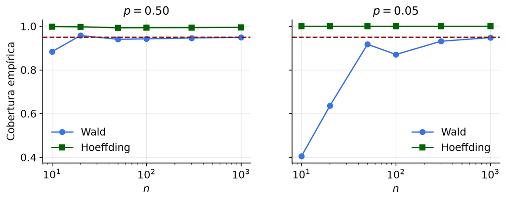

Cobertura empírica de los intervalos de Hoeffding y de Wald para una proporción, sobre cinco mil muestras, según n y p. El de Wald se degrada con n pequeño y p cerca de los bordes.

```python
def cobertura(p, n, R=5000, alpha=0.05):
    x = rng.binomial(n, p, R) / n
    se = np.sqrt(x*(1-x)/n)
    wald = np.mean(np.abs(x - p) <= 1.96*se)
    eps = np.sqrt(np.log(2/alpha)/(2*n))
    hoef = np.mean(np.abs(x - p) <= eps)
    return wald, hoef

ns = [10, 20, 50, 100, 300, 1000]
fig, ax = plt.subplots(1, 2, figsize=(9.5, 3), sharey=True)
for a, p in zip(ax, [0.5, 0.05]):
    res = np.array([cobertura(p, n) for n in ns])
    a.plot(ns, res[:, 0], "o-", color=MYBLUE, label="Wald")
    a.plot(ns, res[:, 1], "s-", color=MYGREEN, label="Hoeffding")
    a.axhline(0.95, color=MYRED, ls="--"); a.set_xscale("log"); a.set_xlabel("$n$")
    a.set_title("$p = %.2f$" % p); a.legend()
ax[0].set_ylabel("Cobertura empírica"); plt.show()
```

Con $p = 0{,}05$ y $n = 20$ el intervalo de Wald cubre mucho menos del 95 % nominal, porque la aproximación normal es mala cuando $np$ es pequeño. Este comportamiento importa en la práctica cuando se estiman proporciones pequeñas por estrato, como en la tarea.

## 2.3 Contraste de hipótesis

En un contraste de hipótesis se parte de una teoría por omisión, la **hipótesis nula**, y se pregunta si los datos aportan evidencia suficiente para rechazarla. Si no la aportan, la hipótesis nula se retiene. En el ejemplo de la moneda, $X_1, \ldots, X_n \sim \text{Bernoulli}(p)$, se contrasta $H_0 : p = 1/2$ contra $H_1 : p \neq 1/2$, y parece razonable rechazar $H_0$ si $T = |\hat p_n - 1/2|$ es grande. Cuánto de grande es la pregunta que responde el apunte IV.

# 3 La función de distribución empírica

El primer problema de inferencia que se resuelve es la estimación no paramétrica de $F$. Sea $X_1, \ldots, X_n \sim F$ una muestra iid.

**Definición.** La **función de distribución empírica** $\hat F_n$ es la función de distribución que asigna masa $1/n$ a cada dato,
$$\hat F_n(x) = \frac{1}{n}\sum_{i=1}^n \mathbf{1}\{X_i \le x\}.$$

Para cada $x$ fijo, $\hat F_n(x)$ es una proporción de indicadores Bernoulli con parámetro $F(x)$, de donde $\mathbb{E}(\hat F_n(x)) = F(x)$, $\mathbb{V}(\hat F_n(x)) = F(x)(1 - F(x))/n$ y $\hat F_n(x) \xrightarrow{P} F(x)$. El teorema de **Glivenko y Cantelli** refuerza este resultado a convergencia uniforme, $\sup_x |\hat F_n(x) - F(x)| \xrightarrow{P} 0$. La desigualdad de **Dvoretzky, Kiefer y Wolfowitz** cuantifica la velocidad: para todo $\epsilon > 0$,
$$\mathbb{P}\Big(\sup_x |F(x) - \hat F_n(x)| > \epsilon\Big) \le 2 e^{-2n\epsilon^2}.$$

De la desigualdad DKW se obtiene una **banda de confianza** no paramétrica para $F$. Con $\epsilon_n = \sqrt{\log(2/\alpha)/(2n)}$, $L(x) = \max\{\hat F_n(x) - \epsilon_n, 0\}$ y $U(x) = \min\{\hat F_n(x) + \epsilon_n, 1\}$, se cumple
$$\mathbb{P}\big(L(x) \le F(x) \le U(x) \text{ para todo } x\big) \ge 1 - \alpha$$
para cualquier $F$. La garantía vale para toda $F$, para todo $n$ y simultáneamente para todo $x$, sin supuesto alguno sobre la forma de la distribución.

```
epsilon_n = 0.136
```

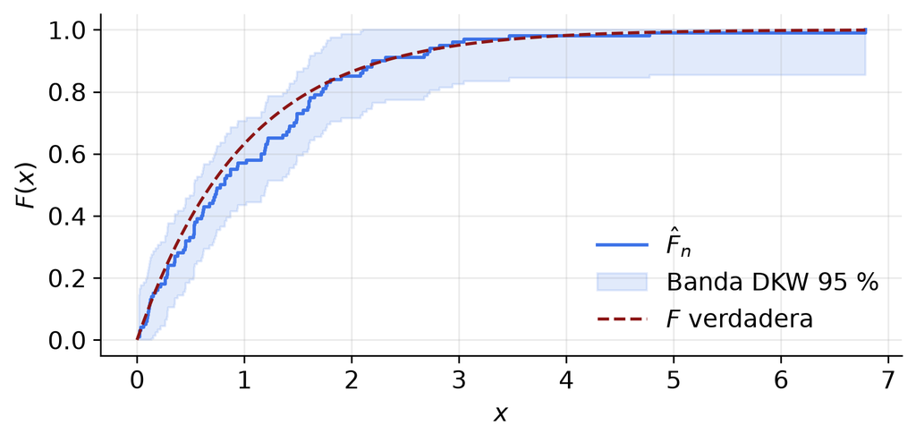

Función de distribución empírica y banda DKW del 95 % para una muestra de 100 tiempos de espera exponenciales, con la distribución verdadera superpuesta.

```python
n = 100
x = np.sort(rng.exponential(1.0, n))
Fn = np.arange(1, n+1) / n
eps = np.sqrt(np.log(2/0.05) / (2*n))
print("epsilon_n = %.3f" % eps)
fig, ax = plt.subplots(figsize=(7, 3))
ax.step(x, Fn, where="post", color=MYBLUE, lw=1.6, label="$\\hat F_n$")
ax.fill_between(x, np.clip(Fn - eps, 0, 1), np.clip(Fn + eps, 0, 1), step="post", color=MYBLUE, alpha=.15, label="Banda DKW 95 %")
g = np.linspace(0, x.max(), 300); ax.plot(g, 1 - np.exp(-g), color=MYRED, ls="--", label="$F$ verdadera")
ax.set_xlabel("$x$"); ax.set_ylabel("$F(x)$"); ax.legend(loc="lower right"); plt.show()
```

Con $n = 100$ la banda tiene semiancho $0{,}136$. Como el ancho decrece con $n^{-1/2}$, reducirlo a la mitad exige cuadruplicar la muestra.

# 4 Funcionales estadísticos y el estimador de sustitución

Un **funcional estadístico** $T(F)$ es cualquier función de $F$. Ejemplos son la media $\mu = \int x\,dF(x)$, la varianza $\sigma^2 = \int (x - \mu)^2\,dF(x)$ y la mediana $m = F^{-1}(1/2)$.

**Definición.** El **estimador de sustitución** (*plug-in*) de $\theta = T(F)$ es $\hat\theta_n = T(\hat F_n)$.

Es decir, se reemplaza la $F$ desconocida por $\hat F_n$. Si $T(F) = \int r(x)\,dF(x)$ para alguna función $r$, el funcional es **lineal** y, como $\hat F_n$ es discreta con masa $1/n$ en cada dato, el estimador de sustitución es
$$T(\hat F_n) = \int r(x)\,d\hat F_n(x) = \frac{1}{n}\sum_{i=1}^n r(X_i).$$

En muchos casos $T(\hat F_n) \approx N(T(F), \widehat{\operatorname{se}}^2)$ y el intervalo basado en la normal es $T(\hat F_n) \pm z_{\alpha/2}\,\widehat{\operatorname{se}}$. La dificultad es obtener $\widehat{\operatorname{se}}$, que sólo en algunos casos tiene forma cerrada.

**La media.** $\hat\mu = \int x\,d\hat F_n(x) = \bar X_n$, con $\operatorname{se} = \sigma/\sqrt n$ y $\widehat{\operatorname{se}} = \hat\sigma/\sqrt n$.

**La varianza.** El estimador de sustitución es $\hat\sigma^2 = \frac1n\sum_i X_i^2 - \big(\frac1n\sum_i X_i\big)^2 = \frac1n\sum_i (X_i - \bar X_n)^2$. La varianza muestral $S_n^2$ divide por $n - 1$; en la práctica la diferencia es irrelevante.

**La asimetría.** $\kappa = \mathbb{E}(X - \mu)^3/\sigma^3$, cuyo estimador de sustitución es $\hat\kappa = \frac1n\sum_i (X_i - \hat\mu)^3 / \hat\sigma^3$.

**La correlación.** $\rho$ es función de cinco funcionales lineales, $T_1 = \int x\,dF$, $T_2 = \int y\,dF$, $T_3 = \int xy\,dF$, $T_4 = \int x^2\,dF$ y $T_5 = \int y^2\,dF$, mediante $\rho = (T_3 - T_1 T_2)/\sqrt{(T_4 - T_1^2)(T_5 - T_2^2)}$. Sustituir cada uno por su versión empírica da la correlación muestral.

**Los cuantiles.** $T(F) = F^{-1}(p)$. Como $\hat F_n$ no es invertible se define $\hat F_n^{-1}(p) = \inf\{x : \hat F_n(x) \ge p\}$, el cuantil muestral.

Sólo para la media se dispone de un error estándar con fórmula. Para la mediana, la asimetría o la correlación hace falta otra herramienta, que es el bootstrap del apunte II.

```python
def plug_in(x):
    Fn_media = x.mean()
    Fn_var = ((x - Fn_media)**2).mean()
    asim = ((x - Fn_media)**3).mean() / Fn_var**1.5
    mediana = np.quantile(x, 0.5)
    return dict(media=Fn_media, varianza=Fn_var, asimetria=asim, mediana=mediana)

x = rng.lognormal(0, 0.6, 400)
est = plug_in(x)
print({k: round(v, 3) for k, v in est.items()})
print("IC 95 %% para la media: (%.3f, %.3f)" % (est["media"] - 1.96*np.sqrt(est["varianza"]/len(x)),
                                              est["media"] + 1.96*np.sqrt(est["varianza"]/len(x))))
```

```
{'media': np.float64(1.178), 'varianza': np.float64(0.664), 'asimetria': np.float64(2.236), 'mediana': np.float64(0.972)}
IC 95 % para la media: (1.098, 1.258)
```

# 5 Un ejemplo completo: diferencia de dos medias

Scott y colaboradores (1978) midieron el colesterol plasmático de 371 pacientes con dolor torácico, 51 sin evidencia de enfermedad cardíaca y 320 con estrechamiento de las arterias. Consideremos los dos grupos como muestras de $F_1$ y $F_2$, con medias $\mu_1$ y $\mu_2$. Las estimaciones de sustitución fueron $\hat\mu_1 = 195{,}27$ y $\hat\mu_2 = 216{,}19$, con $\widehat{\operatorname{se}}(\hat\mu_1) = 5{,}0$ y $\widehat{\operatorname{se}}(\hat\mu_2) = 2{,}4$. El funcional de interés es $\theta = T(F_2) - T(F_1)$, con estimación $\hat\theta = 20{,}92$. Como las muestras son independientes,
$$\operatorname{se}(\hat\theta) = \sqrt{\mathbb{V}(\hat\mu_2) + \mathbb{V}(\hat\mu_1)} = \sqrt{\operatorname{se}(\hat\mu_1)^2 + \operatorname{se}(\hat\mu_2)^2},$$
que se estima en $5{,}55$. El intervalo del 95 % para $\theta$ es $20{,}92 \pm 2 \cdot 5{,}55 = (9{,}8,\; 32{,}0)$. El colesterol es mayor en el grupo con arterias estrechadas. De estos datos no se sigue que el colesterol cause la enfermedad; el paso de la evidencia estadística a la causal es un problema distinto y no forma parte de esta unidad.

```python
def ic_diferencia(x1, x2, alpha=0.05):
    """Intervalo basado en la normal para la diferencia de medias mu2 - mu1."""
    d = x2.mean() - x1.mean()
    se = np.sqrt(x1.var()/len(x1) + x2.var()/len(x2))
    z = stats.norm.ppf(1 - alpha/2)
    return d, se, (d - z*se, d + z*se)

x1 = rng.normal(195, 36, 51); x2 = rng.normal(216, 43, 320)
d, se, ic = ic_diferencia(x1, x2)
print("diferencia = %.1f   se = %.2f   IC 95 %% = (%.1f, %.1f)" % (d, se, *ic))
```

```
diferencia = 22.9   se = 5.29   IC 95 % = (12.5, 33.3)
```

# 6 Síntesis esquemática

Un modelo estadístico es un conjunto de distribuciones, paramétrico si se describe con finitos parámetros. Los tres problemas son estimación puntual, conjuntos de confianza y contraste de hipótesis. Un estimador es una variable aleatoria con sesgo, varianza y distribución muestral; su error estándar es la desviación de esa distribución y en general hay que estimarlo. Un intervalo de confianza de nivel $1-\alpha$ atrapa al parámetro con probabilidad $1-\alpha$ a lo largo de muchos problemas distintos, y no es una afirmación de probabilidad sobre el parámetro. El intervalo de Wald $\hat\theta_n \pm z_{\alpha/2}\widehat{\operatorname{se}}$ es válido asintóticamente; la banda DKW para $F$ es válida para todo $n$. Cualquier característica de $F$ es un funcional $T(F)$ y se estima sustituyendo $F$ por $\hat F_n$. Lo que falta es un método general para el error estándar, y ése es el bootstrap.